# Regression model IV : Diagnostics

The estimation of and inference from the regression model depend on several assumptions. These assumptions should be checked using regression diagnostics before using the model in earnest. We divide the potential problems into three categories:

1. Error : We have assumed that $\epsilon \sim N(0,\sigma^2 I)$, or in words, that the errors are independent, have equal variance and are normally distributed.
2. Model : We have assumed that the structural part of the model, $E(y) = X\beta$, is correct.
3. Unusual observations : Sometimes just a few observations do not fit the model. These few observations might change the choice and fit of the model.

# Checking error assumptions

We wish to check the independence, constant variance and normality of the errors. The errors are not observable, but we can examine the residuals.

$$\hat\epsilon = y - X\hat \beta = (I-H)y.$$

Note that the residuals are not uncorrelated though the errors do.

## constant variance

The most useful diagnostic is a plot of the resuduals against the fitted response. If all is well, you should see constant symmetrical variation (known as homoscedasticity) in the vertical direction.

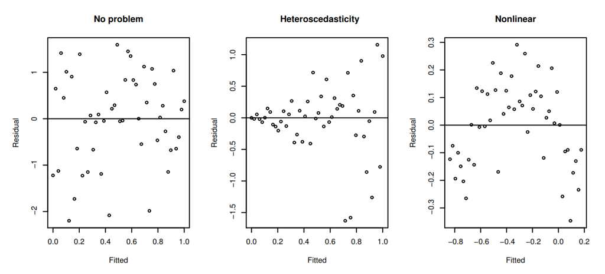

In the above, the left plot is OK, but other two indicate something is violated.

Note] The resuduals against a predictor plot may be also useful.

```r
library(faraway)
data(savings,package="faraway")
str(savings)
```

```
## 'data.frame':    50 obs. of  5 variables:
##  $ sr   : num  11.43 12.07 13.17 5.75 12.88 ...
##  $ pop15: num  29.4 23.3 23.8 41.9 42.2 ...
##  $ pop75: num  2.87 4.41 4.43 1.67 0.83 2.85 1.34 0.67 1.06 1.14 ...
##  $ dpi  : num  2330 1508 2108 189 728 ...
##  $ ddpi : num  2.87 3.93 3.82 0.22 4.56 2.43 2.67 6.51 3.08 2.8 ...
```

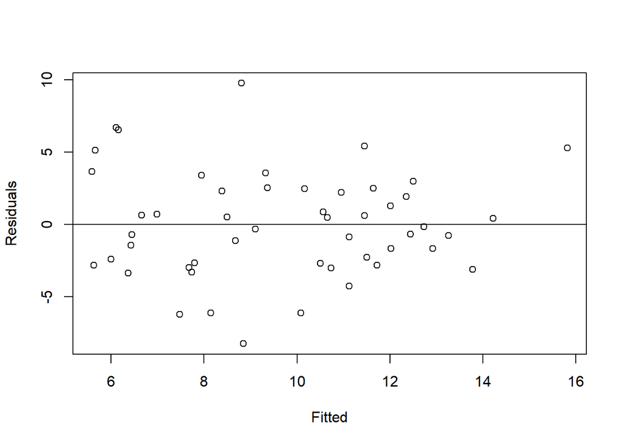

```r
lmod <- lm(sr ~ pop15+pop75+dpi+ddpi,savings)
plot(fitted(lmod),residuals(lmod),xlab="Fitted",ylab="Residuals")
abline(h=0)
```

Q. What do you see in this plot?

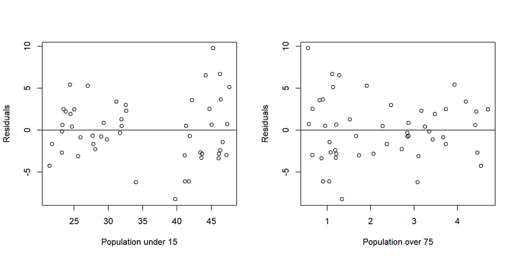

```r
par(mfrow=c(1,2))
plot(savings$pop15,residuals(lmod),  xlab="Population under 15",ylab="Residuals")
abline(h=0)
plot(savings$pop75,residuals(lmod),  xlab="Population over 75",ylab="Residuals")
abline(h=0)
```

On the left panel, there are two groups. we test if the varainces of two groups are equal.

```r
# F-test under the normality assumption
var.test(residuals(lmod)[savings$pop15>35], residuals(lmod)[savings$pop15<35])
```

```
##
##  F test to compare two variances
##
## data:  residuals(lmod)[savings$pop15 > 35] and residuals(lmod)[savings$pop15 < 35]
## F = 2.7851, num df = 22, denom df = 26, p-value = 0.01358
## alternative hypothesis: true ratio of variances is not equal to 1
## 95 percent confidence interval:
##  1.240967 6.430238
## sample estimates:
## ratio of variances
##           2.785067
```

We see a significant difference for variances.

When problems are seen in these diagnostic plots, some modification of the model is suggested.

1. If some non-linearity is observed, perhaps in conjunction with non-constant variance, a transformation of the variables should be considered. See Chaper 9 for more.
2. If the problem is solely one of non-constant variance with no suggestion of nonlinearity then the use of weighted least squares (see Section 8.1) may be appropriate.
3. Alternatively, when non-constant variance is seen in the plot of the residuals against the fitted response, a transformation of the response $y$ to $h(y)$ where $h()$ can be chosen so that $var(h(y))$ is constant.

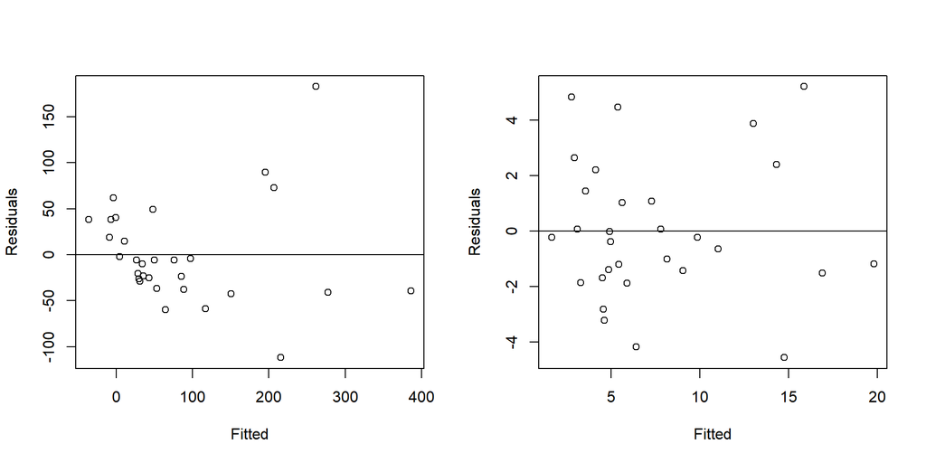

```r
data(gala, package="faraway")
par(mfrow=c(1,2))
lmod <- lm(Species ~ Area + Elevation + Scruz + Nearest  + Adjacent, gala)
plot(fitted(lmod),residuals(lmod),xlab="Fitted",ylab="Residuals")
abline(h=0)
lmod <- lm(sqrt(Species) ~ Area + Elevation + Scruz + Nearest  + Adjacent, gala)
plot(fitted(lmod),residuals(lmod),xlab="Fitted",ylab="Residuals")
abline(h=0)
```

The above plots show that the square-root transformaton of the response make the situation better for `Galapagos` dataset. The Poisson distribution is a good model for counts and that distribution has the property that the mean is equal to the variance, thus suggesting the square root transformation.

## Normality

The tests and confidence intervals we use are based on the assumption of normal errors. The residuals can be assessed for normality using a $Q–Q$ plot. If the erros are normal, the sample quantiles of residuals should coincide with “ideal” normal quantiles. Normal residuals should follow the line approximately.

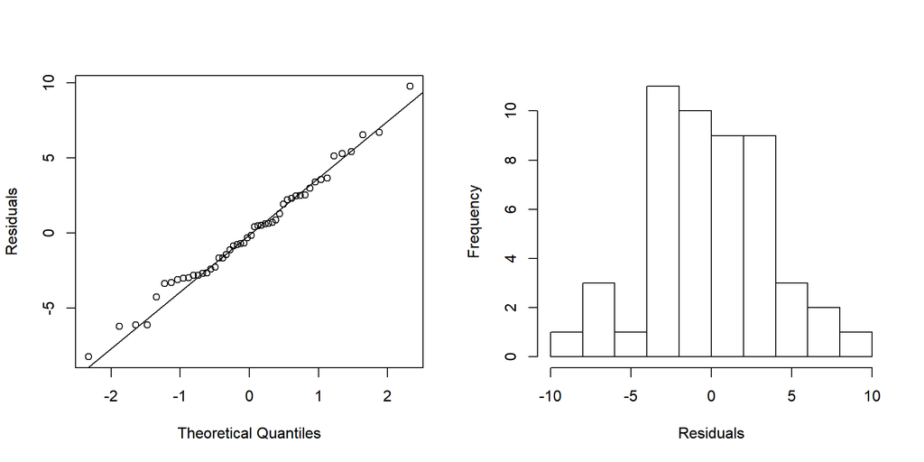

```r
par(mfrow=c(1,2))
lmod <- lm(sr ~ pop15+pop75+dpi+ddpi,savings)
qqnorm(residuals(lmod),ylab="Residuals",main="")
qqline(residuals(lmod))
hist(residuals(lmod),xlab="Residuals",main="")
```

Q. Do you think it is truely normal?

Let us see examples for various distributions by simulation.

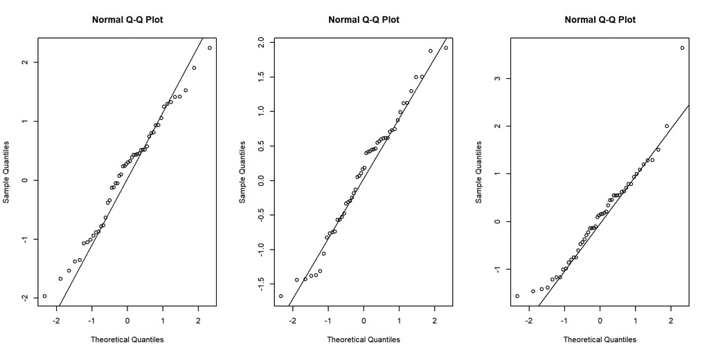

```r
par(mfrow=c(1,3))
n <- 50
for(i in 1:3) {x <- rnorm(n); qqnorm(x); qqline(x)}
```

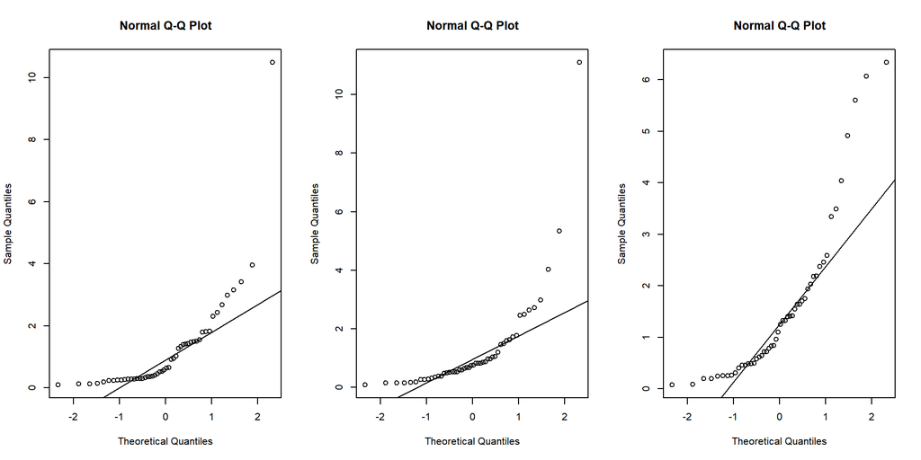

```r
for(i in 1:3) {x <- exp(rnorm(n)); qqnorm(x); qqline(x)}
```

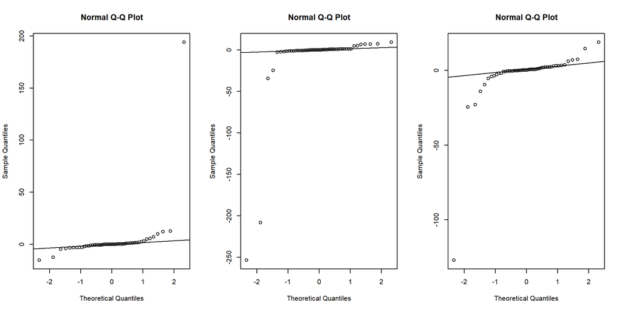

```r
for(i in 1:3) {x <- rcauchy(n); qqnorm(x); qqline(x)}
```

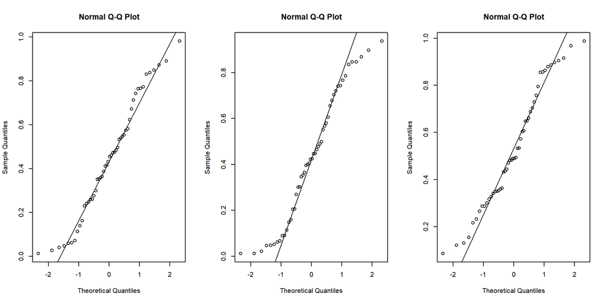

```r
for(i in 1:3) {x <- runif(n); qqnorm(x); qqline(x)}
```

It is not always easy to diagnose the problem in Q–Q plots. Sometimes extreme cases may be a sign of a long-tailed error like the Cauchy distribution or they can be just outliers.

When the errors are not normal, least squares estimates may not be optimal. They will still be best linear unbiased estimates, but other robust estimators may be more effective. Also tests and confidence intervals are not exact. However, we can appeal to the central limit theorem.

When non-normality is found, the resolution depends on the type of problem found.

1. For short-tailed distributions, the consequences of non-normality are not serious and can reasonably be ignored.
2. For skewed errors, a transformation of the response may solve the problem.
3. For long-tailed errors, we might just accept the non-normality and base the inference on the assumption of another distribution or use resampling methods such as the bootstrap or permutation tests. Alternatively, use robust methods, which give less weight to outlying observations but may again require resampling for the inference.

There exist test for normality.

```r
 shapiro.test(residuals(lmod))
```

```
##
##  Shapiro-Wilk normality test
##
## data:  residuals(lmod)
## W = 0.98698, p-value = 0.8524
```

The null hypothesis is normal. It is recommended that this test is used together with a graphical method. (Q-Q plot)

## Correlated errors

It is difficult to check for correlated errors in general because there are just too many possible patterns of correlation that may occur.

Data collected over time may have some correlation in successive errors.

We start by fitting a model with the temperature as the response and the eight proxies as predictors.

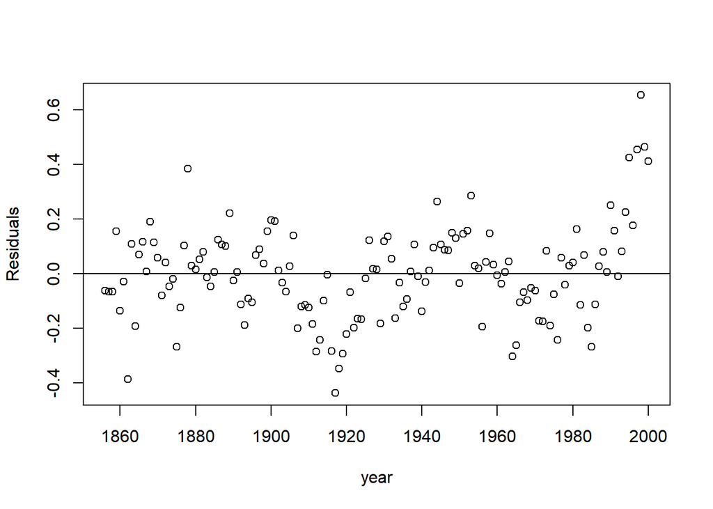

```r
data(globwarm,package="faraway")
lmod <- lm(nhtemp ~ wusa + jasper + westgreen + chesapeake + tornetrask + urals + mongolia + tasman, globwarm)
plot(residuals(lmod) ~ year, na.omit(globwarm), ylab="Residuals")
abline(h=0)
```

We see that the residulas tend to have the same sign successively. This is a common indication for (positively) correlated errors.

$$Corr(\epsilon_i,\epsilon_{i+1})>0$$

Let us draw tne plot of $\hat\epsilon_{i+1}$ against $\hat\epsilon_i$.

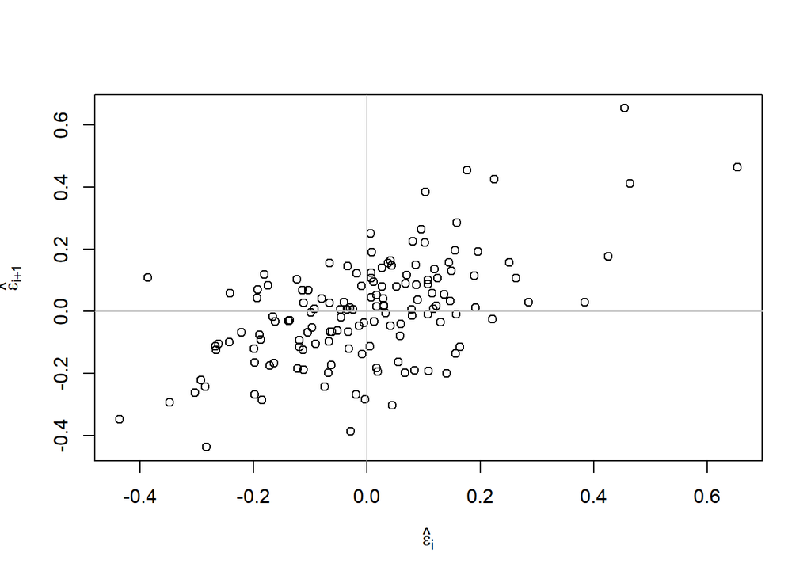

```r
n <- length(residuals(lmod))
plot(tail(residuals(lmod),n-1) ~ head(residuals(lmod),n-1), xlab= expression(hat(epsilon)[i]),ylab=expression(hat(epsilon)[i+1]))
abline(h=0,v=0,col=grey(0.75))
```

```r
cor(tail(residuals(lmod),n-1) ,head(residuals(lmod),n-1))
```

```
## [1] 0.583339
```

```r
sumary(lm(tail(residuals(lmod),n-1) ~ head(residuals(lmod),n-1) -1)) # no intercept
```

```
##                              Estimate Std. Error t value  Pr(>|t|)
## head(residuals(lmod), n - 1) 0.595076   0.069312  8.5855 1.391e-14
##
## n = 144, p = 1, Residual SE = 0.13918, R-Squared = 0.34
```

The Durbin-Watson test if the errors are uncorrelated.

```r
require(lmtest)
dwtest(nhtemp ~ wusa + jasper + westgreen + chesapeake + tornetrask + urals + mongolia + tasman, data=globwarm)
```

```
##
##  Durbin-Watson test
##
## data:  nhtemp ~ wusa + jasper + westgreen + chesapeake + tornetrask +     urals + mongolia + tasman
## DW = 0.81661, p-value = 1.402e-15
## alternative hypothesis: true autocorrelation is greater than 0
```

There is a strong evidence of serial correlation.

# Finding unusual observations

1. outliers
2. influential observations
3. leverage points

Some points may share them.

## leverage points

The $i$th element of the hat matrix $H$, $h_{i}$, is called the leverages. Since $var(\hat\epsilon_i)=\sigma^2(1-h_{i})$, a large $h_i$ makes $var(\hat\epsilon_i)=\sigma^2(1-h_{i})$ small. Therefore, the fit will attracted toward to $y_i$. It is known that a large $h_i$ is due to extreme values in $X$-space.

$\sum_i h_i= p+1$. A rough rule is that leverages of more than $2(p+1)/n$ should be looked at more closely.

```r
lmod <- lm(sr ~ pop15 + pop75 + dpi + ddpi, savings)
hatv <- hatvalues(lmod)
head(hatv)
```

```
##  Australia    Austria    Belgium    Bolivia     Brazil     Canada
## 0.06771343 0.12038393 0.08748248 0.08947114 0.06955944 0.15840239
```

```r
sum(hatv)
```

```
## [1] 5
```

Leverages can also be used in scaling residuals. We have $var(\hat\epsilon_i)=\sigma^2(1-h_{i})$ which suggests the use of:

$$r_i = \frac{\hat\epsilon_i}{\hat\sigma\sqrt{1-h_i}}$$

This is called standardized residuls and simetimes preferred in residual plots.

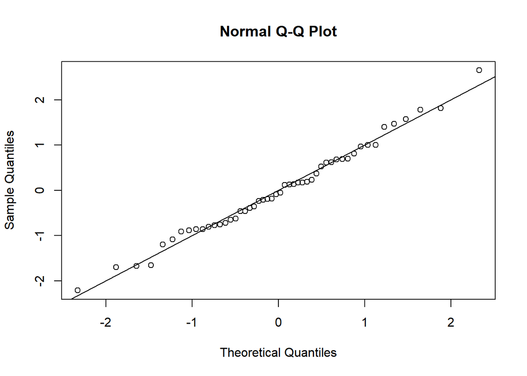

```r
qqnorm(rstandard(lmod))
abline(0,1)
```

## outliers

An outlier is a point that does not fit the current model well. We need to be aware of such exceptions. Outliers may or may not affect the fit substantially.

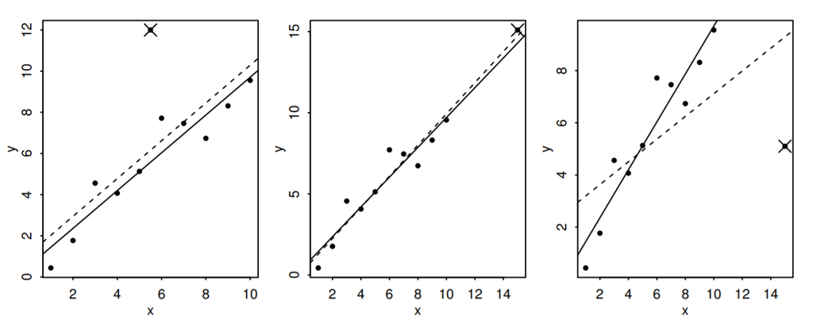

Some points to consider about outliers:

1. An outlier in one model may not be an outlier in another when the variables have been changed or transformed. You will usually need to reinvestigate the question of outliers when you change the model.
2. The error distribution may not be normal and so larger residuals may be expected. For example, day-to-day changes in stock indices seem mostly normal, but larger changes occur from time to time.
3. Individual outliers are usually much less of a problem in larger datasets. A single point will not have the leverage to affect the fit very much.

What should be done about outliers?

1. Check for a data-entry error first.
2. Examine the physical context — why did it happen? One example of the importance of outliers is in the statistical analysis of credit card transactions. Outliers may represent fraudulent use. In such examples, the discovery of outliers is the main purpose of the modeling.
3. Exclude the point from the analysis but try reincluding it later if the model is changed. To avoid any suggestion of dishonesty, always report the existence of outliers even if you do not include them in your final model.
4. Suppose you find outliers that cannot reasonably be identified as mistakes or aberrations, but are viewed as naturally occurring. Particularly if there are substantial numbers of such points, it is more efficient and reliable to use robust regression.
5. It is dangerous to exclude outliers in an automatic manner.

> Ex : `star` dataset

```r
data(star, package="faraway")
str(star)
```

```
## 'data.frame':    47 obs. of  3 variables:
##  $ index: num  1 2 3 4 5 6 7 8 9 10 ...
##  $ temp : num  4.37 4.56 4.26 4.56 4.3 4.46 3.84 4.57 4.26 4.37 ...
##  $ light: num  5.23 5.74 4.93 5.74 5.19 5.46 4.65 5.27 5.57 5.12 ...
```

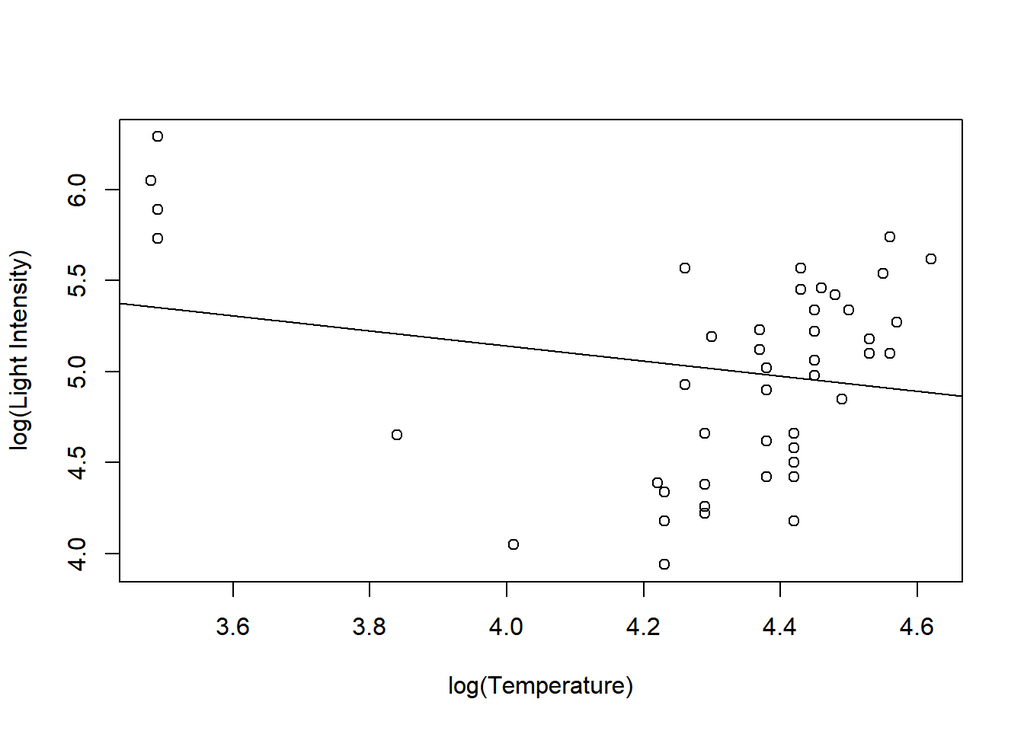

```r
plot(star$temp,star$light,xlab="log(Temperature)",  ylab="log(Light Intensity)")
lmod <- lm(light ~ temp, star)
abline(lmod)
```

```r
range(rstudent(lmod))  # `rstudent` function computs the studentized residuals distributed as t(n-p)
```

```
## [1] -2.049393  1.905847
```

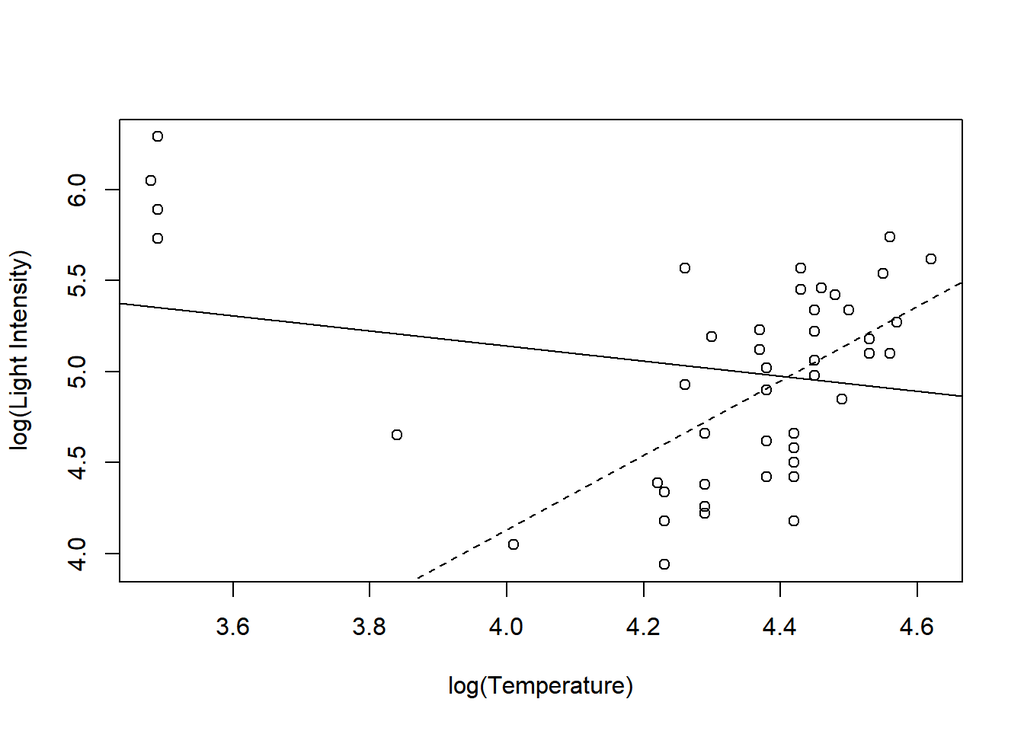

```r
lmodi <- lm(light ~ temp, data=star, subset=(temp>3.6))
plot(star$temp,star$light,xlab="log(Temperature)",  ylab="log(Light Intensity)")
abline(lmod)
abline(lmodi,lty=2)
```

Big changes!

## Influential points

An influential point is one whose removal from the dataset would cause a large change in the fit.

An influential point may or may not be an outlier and may or may not have large leverage but it will tend to have at least one of these two properties. There are several measures of influence.

The Cook statistics : changes in $\beta$ with and wothout $i$th observation

$$D_i = \frac{1}{p+1}r_i^2 \frac{h_i}{1-h_i}$$

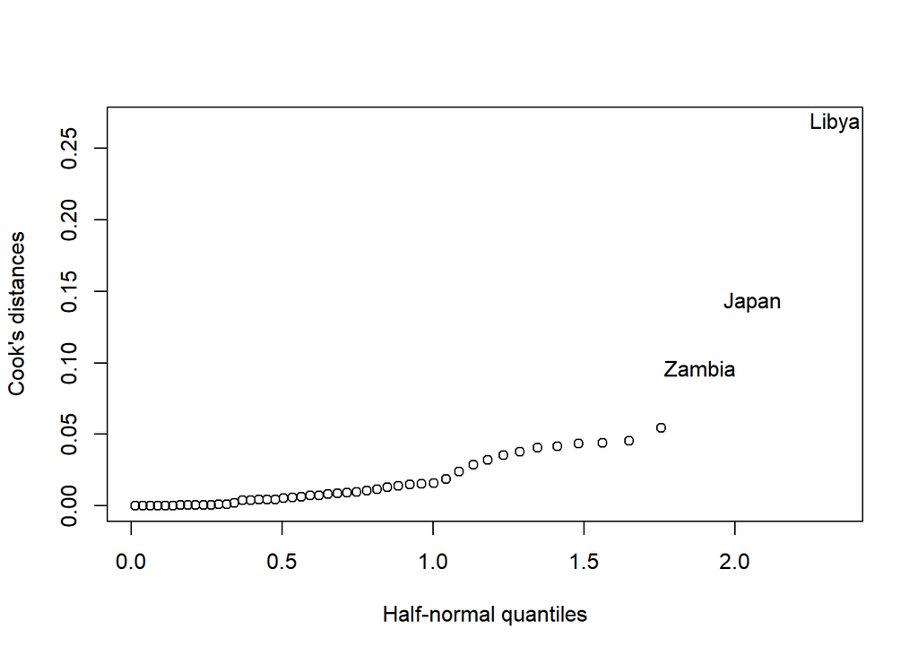

```r
lmod <- lm(sr ~ pop15+pop75+dpi+ddpi,savings)
cook <- cooks.distance(lmod)
halfnorm(cook,3,labs=row.names(savings),ylab="Cook's distances",pch=20)
```

```r
lmodi <- lm(sr ~ pop15+pop75+dpi+ddpi,savings,subset=(cook < max(cook)))
sumary(lmodi)
```

```
##                Estimate  Std. Error t value Pr(>|t|)
## (Intercept) 24.52404598  8.22402631  2.9820 0.004655
## pop15       -0.39144013  0.15790949 -2.4789 0.017084
## pop75       -1.28086692  1.14518206 -1.1185 0.269430
## dpi         -0.00031890  0.00092933 -0.3432 0.733119
## ddpi         0.61027903  0.26877842  2.2706 0.028122
##
## n = 49, p = 5, Residual SE = 3.79481, R-Squared = 0.36
```

```r
sumary(lmod)
```

```
##                Estimate  Std. Error t value  Pr(>|t|)
## (Intercept) 28.56608654  7.35451611  3.8842 0.0003338
## pop15       -0.46119315  0.14464222 -3.1885 0.0026030
## pop75       -1.69149768  1.08359893 -1.5610 0.1255298
## dpi         -0.00033690  0.00093111 -0.3618 0.7191732
## ddpi         0.40969493  0.19619713  2.0882 0.0424711
##
## n = 50, p = 5, Residual SE = 3.80267, R-Squared = 0.34
```

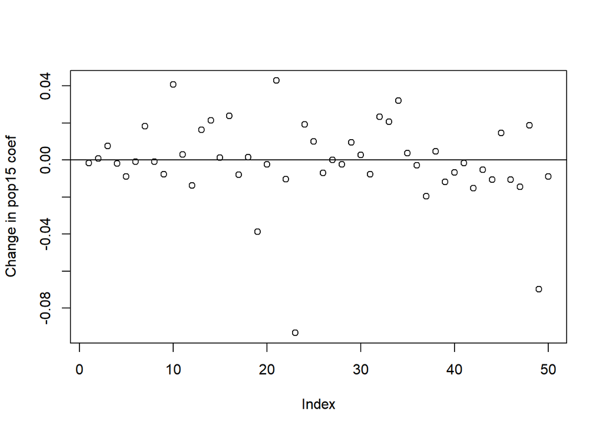

```r
plot(dfbeta(lmod)[,2],ylab="Change in pop15 coef")
abline(h=0)
```

R provides an easy way to produce a useful selection of residual plots

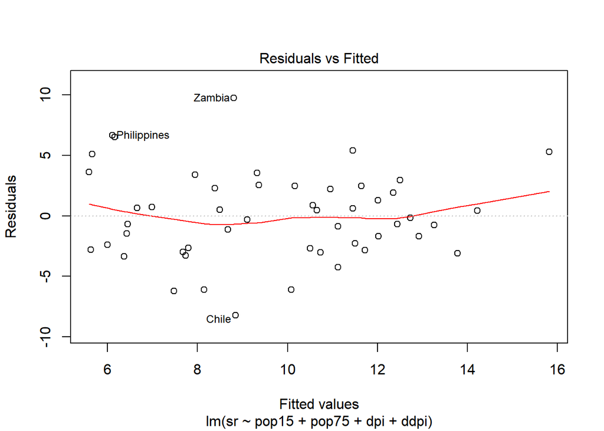

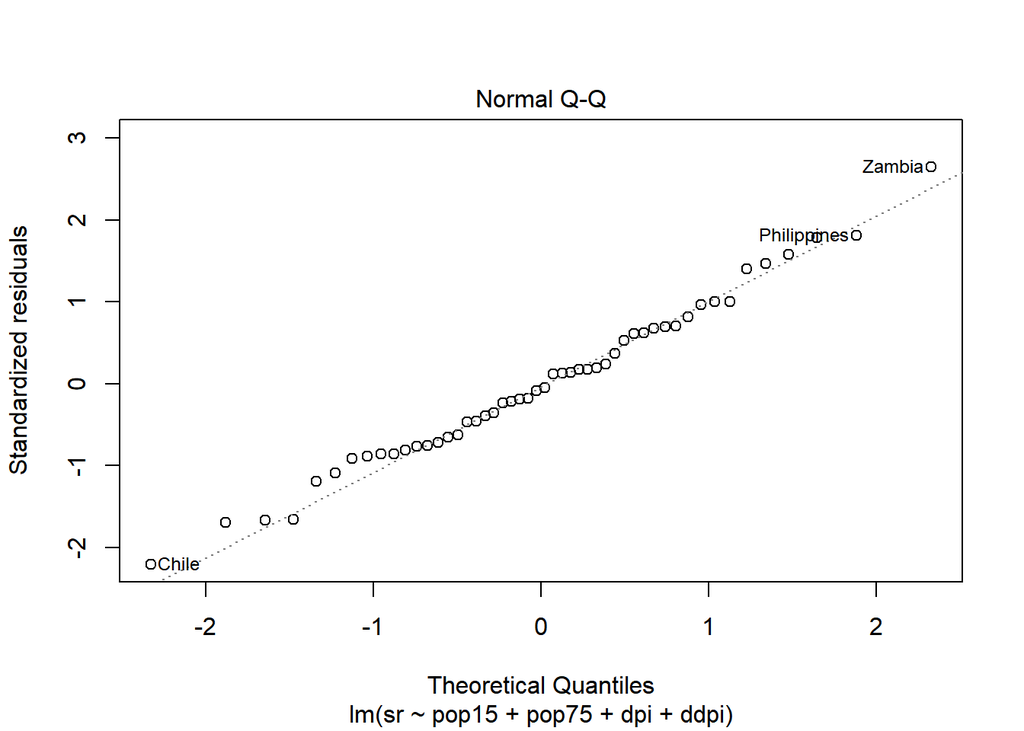

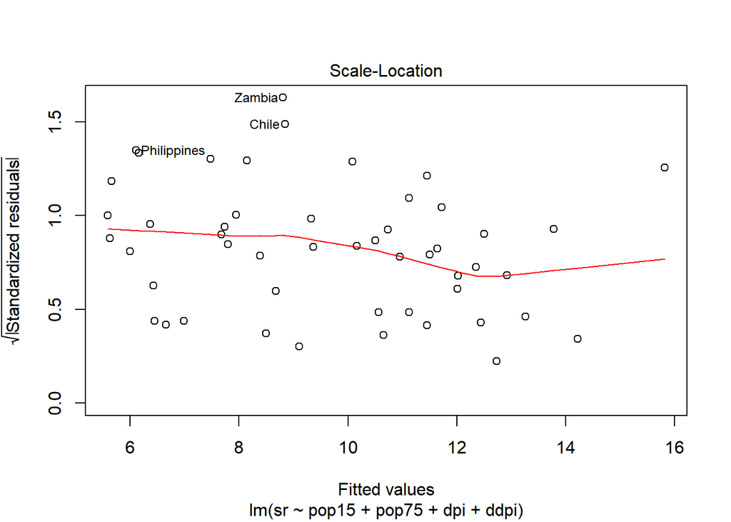

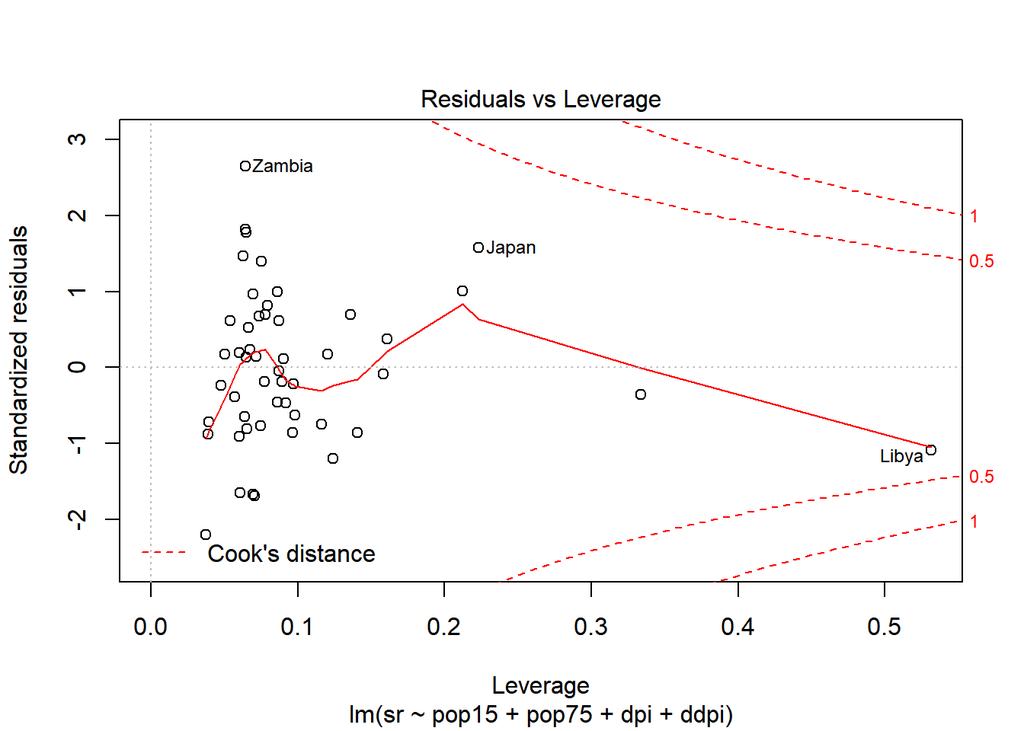

```r
plot(lmod)
```

## checking the structure of the model

Diagnostics can also be used to detect deficiencies i)n the structural part of the model, given by $E(Y) = X\beta$. The residuals are the best clues because signs of remaining systematic structure here indicate that something is wrong.

# Discussions

Some assumptions a more important than others because some violations are more serious in that they can lead to very misleading conclusions. We can order these assumptions according to their importance:

1. The systematic form of the model. If you get this seriously wrong, then predictions will be inaccurate and any explanation of the relationship between the variables may be biased in misleading ways.
2. Dependence of errors. The presence of strong dependence means that there is less information in the data than the sample size may suggest. Furthermore, there is a risk that the analyst will mistakenly introduce systematic components to the model in an attempt to deal with an unsuspected dependence in the errors. Unfortunately, it is difficult to detect dependence in the errors using regression diagnostics except in special situations such as temporal data. For other types of data, the analyst will need to rely on less testable assumptions about independence based on contextual knowledge.
3. Nonconstant variance. A failure to address this violation of the linear model assumptions may result in inaccurate inferences. In particular, prediction uncertainty may not be properly quantified. Even so, excepting serious violations, the adequacy of the inference may not be seriously compromised.
4. Normality. This is the least important assumption. For large datasets, the inference will be quite robust to a lack of normality as the central limit theorem will mean that the approximations will tend to be adequate. Unless the sample size is quite small or the errors very strongly abnormal, this assumption is not crucial to success.

# Exercise

# 1 in page in Chapter 6 (page 97)